# FastQC on bulk RNAseq data

Xiting Yan

05/25/2021

# Background

# FastQC

## Apply FastQC

Input for this style includes:

- data.dir: folder containing a list of folders, each of which contains fastq files for a given sample. no other files should exist under these folders other than the fastq.gz files.
- work.dir: folder where to save the scripts and the FastQC results.
- fastq.filepath: location of the executable file for FastQC.

```r
# This chunck needs to be run on the hpc.
# Since our samples were saved in two different folders, we run this chunck for each data.dir separately.
#data.dir<-"/home/xy48/scratch/Shervin/data/sample_dir_000005540"
work.dir<-file.path(home.dir,"scratch60/Laura_Koth")
data.dir<-file.path(work.dir,"fastq")

fastqc.filepath<-"/home/xy48/scratch_kaminski/public/softwares/FastQC_v0.11.5/fastqc" # This has to be a location on the hpc.

script.dir<-file.path(work.dir,"scripts_FastQC")
output.dir<-file.path(work.dir,"results_FastQC")

if(file.exists(script.dir)==F){
  dir.create(script.dir)
}

if(file.exists(output.dir)==F){
  dir.create(output.dir)
}

jobsub.filepath<-file.path(script.dir,"jobsub.bat")
if(file.exists(jobsub.filepath)){
  file.remove(jobsub.filepath)
}
file.create(jobsub.filepath)

# get the list of folders under data.dir
filenames<-list.files(data.dir)

# we generate one sh file for each sample separately.
for(i in 1:length(filenames)){
  sample.name<-my.element.extract(filenames[i],splitchar="\\.",index=1)
  script.filepath<-file.path(script.dir,paste(sample.name,".sh",sep=""))
  output.subdir<-file.path(output.dir,sample.name)
  if(file.exists(output.subdir)==F){
    dir.create(output.subdir)
  }

  # generate the header for the sh file
  cmd.out<-"#!/bin/bash\n"
  cmd.out<-paste(cmd.out,"#SBATCH --partition=day,pi_kaminski\n",sep="")
  cmd.out<-paste(cmd.out,"#SBATCH --job-name=",sample.name,"\n",sep="")
  cmd.out<-paste(cmd.out,"#SBATCH --ntasks=1\n",sep="")
  cmd.out<-paste(cmd.out,"#SBATCH --cpus-per-task=10\n",sep="")
  cmd.out<-paste(cmd.out,"#SBATCH --mem-per-cpu=10G\n",sep="")
  cmd.out<-paste(cmd.out,"#SBATCH --time=1-00:00:00\n",sep="")

  fastq.filepath<-file.path(data.dir,filenames[i])
  temp<-paste(fastqc.filepath," -o ",output.subdir," -t 10 ",fastq.filepath,"\n",sep="")
  cmd.out<-paste(cmd.out,paste(temp,collapse="\n"),sep="")
  cat(cmd.out,file=script.filepath,append=F)

  cat("sbatch < ",script.filepath,"\n",sep="",file=jobsub.filepath,append=T)
}
system(paste("chmod 700 ",jobsub.filepath,sep=""))
```

## FastQC Summary

We load in the results and generate a summary of the fastQC results.

First, we unzip the zip files generated by FastQC.

```r
# These codes were run directy on the HPC

# First, we unzip the FastQC report zip files
result.dir<-"/home/xy48/scratch60/Laura_Koth/results_FastQC"
sample.names<-list.files(result.dir)

for(i in 1:length(sample.names)){
  filenames<-list.files(file.path(result.dir,sample.names[i]))
  filenames<-filenames[grep(".zip",filenames)]
  for(j in 1:length(filenames)){
    unzip(file.path(result.dir,sample.names[i],filenames[j]),exdir=file.path(result.dir,sample.names[i]))
  }
}
```

Second, extract the results across different files and merge them into one single file.

```r
# These codes were run directy on the HPC
###########
# Second, we extract the results and export it into a spreadsheet.
source("~/Rprogram/my_functions.R")
result.dir<-"/home/xy48/scratch60/Laura_Koth/results_FastQC"
output.filepath<-"/home/xy48/scratch60/Laura_Koth/FastQC_results_table_b2trimming.txt"
sample.names<-list.files(result.dir)
cmd.out<-cmd.out<-data.frame()
filenames.vect<-character()
for(i in 1:length(sample.names)){

  result.subdir<-file.path(result.dir,sample.names[i])
  temp.dirs<-list.dirs(result.subdir,full.names=F,recursive = FALSE)
  input.filenames<-file.path(temp.dirs,"summary.txt")
  filenames.vect<-c(filenames.vect,temp.dirs)
  input.filepath<-file.path(result.subdir,input.filenames)

  my.data.1<-data.frame()
  for(j in 1:length(input.filepath)){
    temp.text<-as.matrix(read.table(input.filepath[j],sep="\t",header=F,check.names=F))
    temp.values<-temp.text[,1]
    names(temp.values)<-temp.text[,2]
    if(i==1 & j==1){
      my.rownames<-temp.text[,2]
    }
    my.data.1<-rbind(my.data.1,as.data.frame(t(temp.values)))
  }

  input.filenames<-file.path(temp.dirs,"fastqc_data.txt")
  input.filepath<-file.path(result.subdir,input.filenames)
  my.data<-data.frame()
  for(j in 1:length(input.filepath)){
    temp.text<-readLines(input.filepath[j])

    # get the total number of reads
    temp.rn<-my.element.extract(temp.text[grep("Total Sequences",temp.text)],splitchar="\t",index=-1)
    total.read.num<-as.numeric(temp.rn)
    # extract the overrepresented sequences
    temp.end.index<-grep(">>END_MODULE",temp.text)
    over.start<-grep(">>Overrepresented sequences",temp.text)
    over.end<-min(temp.end.index[temp.end.index>over.start])
    adapter.start<-grep(">>Adapter Content",temp.text)
    adapter.end<-min(temp.end.index[temp.end.index>adapter.start])
    file.end<-length(temp.text)

#    my.temp<-c(my.temp,my.element.extract(temp.text[over.start+2],splitchar="\t",index=1))
    if(temp.text[over.start+1]==">>END_MODULE"){
      my.temp<-data.frame(overrepresented_sequence="")
    }else{
      my.temp<-data.frame(overrepresented_sequence=my.element.extract(temp.text[over.start+2],splitchar="\t",index=1))
    }
    my.temp<-cbind(total.read.num,my.temp)
    colnames(my.temp)[1]<-"total_read_num"
    temp.names<-unlist(strsplit(temp.text[adapter.start+1],split="\t"))
    temp.values<-unlist(strsplit(temp.text[adapter.end-1],split="\t"))
    temp.values<-temp.values[-1]
    names(temp.values)<-temp.names[2:length(temp.names)]
    temp.values<-as.data.frame(t(temp.values))
    my.temp<-cbind(my.temp,temp.values)
    my.data<-rbind(my.data,my.temp)
  }
  my.data<-cbind(my.data.1,my.data)

  cmd.out<-rbind(cmd.out,my.data)
}
temp1<-sapply(filenames.vect,my.element.remove,splitchar="_",index=-1)
temp1<-sapply(temp1,my.element.remove,splitchar="_",index=-1)
rownames(cmd.out)<-temp1

# output the table
cat("filenames\t",file=output.filepath,append=F)
write.table(cmd.out,file=output.filepath,sep="\t",row.names=T,col.names=T,quote=F,append=T)
```

## Conclusions

We did not see significant adapter contamination in the data. Therefore, we’ll directly map these reads to human genome.

# STAR mapping

We use STAR to map all the reads to human genome.

## Build STAR Index

We generate the index file using the following command in terminal.

[output not shown]

## Mapping

We use STAR to map all the reads to human genome UCSC hg38. This dataset is a single-end data.

```r
# this chunck needs to be run on the HPC directly
# There's only one fastq file for each end. Needs to be changed if there are multiple parts.
home.dir<-"/home/xy48"
source(file.path(home.dir,"Rprogram/my_functions.R"))
work.dir<-file.path(home.dir,"scratch60/Laura_Koth")
data.dir<-file.path(work.dir,"fastq")
star.index.dir<-file.path(work.dir,"STAR_index")
sjdb.filepath<-"/home/xy48/scratch_kaminski/public/genomes/Homo_sapiens/UCSC/hg38/Annotation/Archives/archive-current/Genes/genes.gtf"

script.dir<-file.path(work.dir,"scripts_STAR")
output.dir<-file.path(work.dir,"results_STAR")

if(file.exists(script.dir)==F){
  dir.create(script.dir)
}

if(file.exists(output.dir)==F){
  dir.create(output.dir)
}

jobsub.filepath<-file.path(script.dir,"jobsub.bat")
if(file.exists(jobsub.filepath)){
  file.remove(jobsub.filepath)
}
file.create(jobsub.filepath)

# In this data, each sample has one fastq file.
filenames<-list.files(data.dir)
temp<-unname(sapply(filenames,my.element.extract,splitchar="_",index=4))
filenames<-filenames[!temp%in%c("UHR","R1")]
# get ride of the two samples with no phenotype assignment

sample.names<-unname(sapply(filenames,my.element.extract,splitchar="\\.",index=1))

for(i in 1:length(sample.names)){
  #data.subdir<-file.path(data.dir,sample.names[i])
  temp1<-my.element.extract(sample.names[i],splitchar="_",index=4)
  temp2<-my.element.extract(sample.names[i],splitchar="_",index=5)
  sample.name<-paste0(temp1,"_",temp2)

  output.subdir<-file.path(output.dir,sample.name)
  if(file.exists(output.subdir)==F){
    dir.create(output.subdir)
  }

  # get the list of folders under data.dir
  fastq.filepath<-file.path(data.dir,filenames[i])
  jobname<-sample.name

  script.filepath<-file.path(script.dir,paste(jobname,".sh",sep=""))

  # We assume there's only one part
  temp<-"#!/bin/bash\n"
  temp<-paste0(temp,"#SBATCH --partition=pi_kaminski,day\n")
  temp<-paste0(temp,"#SBATCH --job-name=",jobname,"\n")
  temp<-paste0(temp,"#SBATCH --nodes=1 --cpus-per-task=10 --mem=40Gb\n")
  temp<-paste0(temp,"#SBATCH --time=1-00:00:00\n")
  temp<-paste0(temp,"#SBATCH --mail-type=NONE\n")
  temp<-paste0(temp,"#SBATCH --error=",script.filepath,".e%J\n","#SBATCH --output=",script.filepath,".o%J","\n",sep="")

  # If there are multiple fastq files for each end, after --readFilesIn concatenate them using ,
  #cmd.out<-paste(cmd.out,"STAR --readFilesCommand zcat --outSAMtype BAM SortedByCoordinate --outSAMprimaryFlag AllBestScore --bamRemoveDuplicatesType UniqueIdentical --outSAMstrandField intronMotif --outFilterIntronMotifs RemoveNoncanonical --runThreadN 10 --genomeDir ",star.index.dir," --sjdbGTFfile ",sjdb.filepath," --sjdbOverhang 100 --twopassMode Basic"," --readFilesIn ",paste(filenames.1,collapse=",",sep="")," ",paste(filenames.2,collapse=",",sep="")," --outFileNamePrefix ",file.path(output.subdir,sample.names[i]),sep="")
  temp<-paste(temp,"STAR --readFilesCommand zcat --outSAMtype BAM SortedByCoordinate --outSAMprimaryFlag AllBestScore --bamRemoveDuplicatesType UniqueIdentical --outSAMstrandField intronMotif --outFilterIntronMotifs RemoveNoncanonical --runThreadN 10 --genomeDir ",star.index.dir," --sjdbGTFfile ",sjdb.filepath," --sjdbOverhang 50 --twopassMode Basic"," --readFilesIn ",fastq.filepath," --outFileNamePrefix ",file.path(output.subdir,sample.name),sep="")

  cat(temp,file=script.filepath,append=F)
  cat("sbatch < ",script.filepath,"\n",sep="",file=jobsub.filepath,append=T)
}
system(paste("chmod 700 ",jobsub.filepath,sep=""))
#system(paste("nohup ",script.filepath," > ",log.filepath," &",sep=""))
```

We submit all the jobs by typing `jobsub.bat` in the terminal.

## Mapping Summary

We generate a summary of the mapping results on the STAR output files.

```r
# These codes were run directy on the HPC
rm(list=ls())
source("/home/xy48/Rprogram/my_functions.R")
work.dir<-"/home/xy48/scratch60/Laura_Koth"
data.dir<-file.path(work.dir,"results_STAR")
output.filepath<-file.path(work.dir,"STAR_mapping_summary.txt")

file.names<-list.files(data.dir)
sample.names<-file.names
star.matrix<-numeric()
for(i in 1:length(file.names)){
    filepath<-list.files(file.path(data.dir,file.names[i]))
    filepath<-filepath[grep(".final.",filepath)]
    filepath<-file.path(data.dir,file.names[i],filepath)

    temp<-readLines(filepath)
    # total number of reads
    temp.vect<-as.numeric(my.element.extract(temp[6],splitchar="\t",index=-1))
    # uniquely mapped reads
    temp.vect<-c(temp.vect,as.numeric(my.element.extract(temp[9],splitchar="\t",index=-1)))
    # uniquely mapped rate
    temp.vect<-c(temp.vect,as.numeric(my.element.extract(my.element.extract(temp[10],splitchar="\t",index=-1),splitchar="%",index=1))*0.01)

    # number of multiple loci mapped reads
    temp.vect<-c(temp.vect,as.numeric(my.element.extract(temp[24],splitchar="\t",index=-1)))
    # multi_maprate
    temp.vect<-c(temp.vect,as.numeric(my.element.extract(my.element.extract(temp[25],splitchar="\t",index=-1),splitchar="%",index=1))*0.01)

    # number of too many loci
    temp.vect<-c(temp.vect,as.numeric(my.element.extract(temp[26],splitchar="\t",index=-1)))
    # toomanyloci_maprate
    temp.vect<-c(temp.vect,as.numeric(my.element.extract(my.element.extract(temp[27],splitchar="\t",index=-1),splitchar="%",index=1))*0.01)
    # ummapped_mismatches_rate
    temp.vect<-c(temp.vect,as.numeric(my.element.extract(my.element.extract(temp[29],splitchar="\t",index=-1),splitchar="%",index=1))*0.01)

    # unmapped_tooshort_rate
    temp.vect<-c(temp.vect,as.numeric(my.element.extract(my.element.extract(temp[30],splitchar="\t",index=-1),splitchar="%",index=1))*0.01)
    # unmapped_other_rate
    temp.vect<-c(temp.vect,as.numeric(my.element.extract(my.element.extract(temp[31],splitchar="\t",index=-1),splitchar="%",index=1))*0.01)
    # chimeric reads
    temp.vect<-c(temp.vect,as.numeric(my.element.extract(temp[33],splitchar="\t",index=-1)))
    # chimeric_rate
    temp.vect<-c(temp.vect,as.numeric(my.element.extract(my.element.extract(temp[34],splitchar="\t",index=-1),splitchar="%",index=1))*0.01)

    star.matrix<-rbind(star.matrix,temp.vect)
}

rownames(star.matrix)<-sample.names
colnames(star.matrix)<-c("total","mapped_unique","maprate_unique","mapped_multiloci","maprate_multiloci","mapped_toomanyloci","maprate_toomanyloci","unmaprate_mismatches","unmaprate_tooshort","unmaprate_other","chimeric","chimeric_rate")
star.matrix[,c("total","mapped_unique","mapped_multiloci","mapped_toomanyloci","chimeric")]<-star.matrix[,c("total","mapped_unique","mapped_multiloci","mapped_toomanyloci","chimeric")]*2
star.matrix<-cbind(rownames(star.matrix),star.matrix)
colnames(star.matrix)[1]<-"sample_names"
write.table(star.matrix,file=output.filepath,append=F,sep="\t",row.names=F,col.names=T,quote=F)
```

# Count matrices

We generate the raw count and the DESeq2 normalized data based on the mapping results.

## Raw count matrix

First, we generate the raw count for each sample separately.

```r
library(Rsubread)
library(edgeR)
source("~/Rprogram/my_functions.R")

#output.dir<-"/home/xy48/scratch60/Laura_Koth/results_rawcounts"
#tophat.dir<-"/home/xy48/scratch60/Laura_Koth/results_STAR"
#j=1

###############################
# load in the IDs that need to be switched with each other
dir.list<-list.files(tophat.dir)
count.table<-numeric()

result.dirs<-dir.list
#for(j in 1:length(result.dirs)){

sample.name<-result.dirs[j]

temp.files<-list.files(file.path(tophat.dir,result.dirs[j]))
temp.files<-temp.files[grep("out.bam",temp.files)]
bam.filepath<-file.path(tophat.dir,result.dirs[j],temp.files)

temp<-featureCounts(bam.filepath,annot.inbuilt="hg38",annot.ext="/home/ysm/xiting_yan/xy48/scratch_kaminski/public/genomes/Homo_sapiens/UCSC/hg38/Annotation/Archives/archive-2015-08-14-08-18-15/Genes/genes.gtf",isGTFAnnotationFile=T,GTF.featureType="exon",GTF.attrType="gene_id",useMetaFeatures=T,allowMultiOverlap=T,nthreads=1,countMultiMappingReads=T)

anno.matrix<-temp[[2]]
count.table<-cbind(count.table,temp[[1]])

colnames(count.table)<-sample.name

cmd.out<-cbind(anno.matrix,count.table)
output.filepath<-file.path(output.dir,paste(sample.name,"_rawcounts.txt",sep=""))
write.table(cmd.out,file=output.filepath,append=F,sep="\t",row.names=F,col.names=T,quote=F)
#}
```

We generate the sh file to apply the codes above to each sample in parallele.

```r
source("/home/xy48/Rprogram/my_functions.R")

r.filepath<-"/home/xy48/scratch60/Laura_Koth/rawcount_persample.R"
tophat.dir<-"/home/xy48/scratch60/Laura_Koth/results_STAR"
work.dir<-"/home/xy48/scratch60/Laura_Koth"

script.dir<-file.path(work.dir,"scripts_rawcounts_hg38")
output.dir<-file.path(work.dir,"results_rawcounts_hg38")

if(file.exists(script.dir)==F){
dir.create(script.dir)
}

if(file.exists(output.dir)==F){
dir.create(output.dir)
}


jobsub.filepath<-file.path(script.dir,"jobsub.bat")
if(file.exists(jobsub.filepath)){
file.remove(jobsub.filepath)
}
file.create(jobsub.filepath)

filenames<-list.files(tophat.dir)
sample.names<-filenames

for(i in 1:length(sample.names)){

script.filepath<-file.path(script.dir,paste(sample.names[i],".sh",sep=""))

# generate the header for slurm
cmd.out<-"#!/bin/bash\n#SBATCH --partition=day,pi_kaminski,week\n#SBATCH --ntasks=1 --nodes=1 --cpus-per-task=1\n#SBATCH --mem=8152\n#SBATCH --time=24:00:00\n#SBATCH --mail-type=NONE\n"
cmd.out<-paste(cmd.out,"#SBATCH --job-name=",sample.names[i],"\n",sep="")
cmd.out<-paste(cmd.out,"#SBATCH --error=",script.filepath,".e%J\n",sep="")
cmd.out<-paste(cmd.out,"#SBATCH --output=",script.filepath,".o%J\n",sep="")

cmd.out<-paste(cmd.out,"R --vanilla<<EOF\n",sep="")
cmd.out<-paste(cmd.out,"tophat.dir<-\"",tophat.dir,"\"\n",sep="")
cmd.out<-paste(cmd.out,"output.dir<-\"",output.dir,"\"\n",sep="")
cmd.out<-paste(cmd.out,"j=",i,"\n",sep="")
cmd.out<-paste(cmd.out,"source(\"",r.filepath,"\")\n",sep="")
cmd.out<-paste(cmd.out,"EOF\n",sep="")

cat(cmd.out,file=script.filepath,append=F)
cat("sbatch < ",script.filepath,"\n",sep="",file=jobsub.filepath,append=T)

system(paste("chmod 700 ",script.filepath,sep=""))
}
system(paste("chmod 700 ",jobsub.filepath,sep=""))
```

We merge the raw count of different samples into the same matrix.

```r
# These codes can be run both on a workstation or on grace HPC. It only takes one single thread.
source("~/Rprogram/my_functions.R")

output.dir<-"/home/xy48/scratch60/Laura_Koth/results_rawcounts_hg38"
tophat.dir<-"/home/xy48/scratch60/Laura_Koth/results_STAR"
output.filepath<-"/home/xy48/scratch60/Laura_Koth/rawcounts_all.txt"

###############################
# load in the IDs that need to be switched with each other
dir.list<-list.files(tophat.dir)
dir.samplenames<-dir.list
count.table<-numeric()
result.dirs<-dir.list

for(j in 1:length(result.dirs)){

sample.name<-dir.samplenames[j]
count.filepath<-file.path(output.dir,paste(sample.name,"_rawcounts.txt",sep=""))

temp<-read.table(count.filepath,sep="\t",header=T,check.names=F)
rownames(temp)<-temp[,1]

if(j==1){
anno.matrix<-temp[,1:6]
count.table<-cbind(count.table,temp[,7])
gene.names<-anno.matrix[,1]
}else{
count.table<-cbind(count.table,temp[gene.names,7])
}
}

colnames(count.table)<-dir.samplenames
cmd.out<-cbind(anno.matrix,count.table)
write.table(cmd.out,file=output.filepath,append=F,sep="\t",row.names=F,col.names=T,quote=F)
```

## DESeq2 Normalized count

Based on the raw count matrix, we generate the DESeq2 normalized data.

```r
# In this note, we use DESeq2 to normalize the raw counts
# These codes can be run both on the HPC and on local machine.
# Specification of home.dir decides which machine this is run.

# https://hbctraining.github.io/DGE_workshop/lessons/02_DGE_count_normalization.html

####################################
# 0. load in the raw count matrix and generate the
library(DESeq2)
home.dir<-"/home/yanxiting/driver_Grace"
source(file.path(home.dir,"Rprogram/my_functions.R"))

rawcount.filepath<-file.path(home.dir,"scratch60/Laura_Koth/rawcounts_all.txt")
rawcount.matrix<-read.table(rawcount.filepath,sep="\t",header=T,check.names=F)

annot.matrix<-rawcount.matrix[,1:6]
data.matrix<-rawcount.matrix[,7:ncol(rawcount.matrix)]

# generate the meta data
#meta.data<-readRDS(file.path(home.dir,"scratch/GRADS/SARC_results/Results_summary_PBMC_hg38/baseline/data/clinic_matrix_merged.RDS"),refhook = NULL)
temp.vect<-unname(sapply(colnames(data.matrix),my.element.extract,splitchar="_",index=1))
temp.vect[temp.vect=="duplicate"]<-"sarcoidosis"
meta.data<-data.frame(samples=colnames(data.matrix),disease=temp.vect)
rownames(meta.data)<-colnames(data.matrix)
# match the row names of meta data and the column names of data.matrix
meta.data<-meta.data[colnames(data.matrix),]

dds <- DESeqDataSetFromMatrix(countData = data.matrix, colData = meta.data, design = ~ 1)
#View(counts(dds))
dds <- estimateSizeFactors(dds)
sizeFactors(dds)

normalized_counts <- counts(dds, normalized=TRUE)

cmd.out<-cbind(annot.matrix,normalized_counts)

# output the normalized counts
output.filepath<-file.path(home.dir,"scratch60/Laura_Koth","DESeq2_normalized.txt")
write.table(cmd.out,file=output.filepath,append=F,sep="\t",row.names=F,col.names=T,quote=F)

output.filepath<-file.path(home.dir,"scratch60/Laura_Koth","DESeq2_normalized.RDS")
saveRDS(cmd.out,file=output.filepath,refhook = NULL)
```

## TPM

First, we calculate the TPMs for each sample separately.

```r
# These codes need to be run directly on grace HPC.
star.dir<-"/home/xy48/scratch/Shervin/results_STAR"
gtf.filepath<-"/home/xy48/scratch_kaminski/public/genomes/Homo_sapiens/UCSC/hg38/Annotation/Archives/archive-current/Genes/genes.gtf"
folder.names<-list.files(star.dir)
work.dir<-"/home/xy48/scratch/Shervin"
source("~/Rprogram/my_functions.R")


output.dir<-file.path(work.dir,"results_TPMcalculator_hg38")
script.dir<-file.path(work.dir,"scripts_TPMcalculator_hg38")

if(file.exists(output.dir)==F){
  dir.create(output.dir)
}

if(file.exists(script.dir)==F){
  dir.create(script.dir)
}

jobsub.filepath<-file.path(script.dir,"jobsub.bat")
if(file.exists(jobsub.filepath)){
  file.remove(jobsub.filepath)
}
file.create(jobsub.filepath)

for(i in 1:length(folder.names)){

  temp.name<-my.element.extract(folder.names[i],splitchar="_",index=2)

  output.subdir<-file.path(output.dir,temp.name)
  if(file.exists(output.subdir)==F){
    dir.create(output.subdir)
  }

  script.filepath<-file.path(script.dir,paste(temp.name,".sh",sep=""))
  bam.filepath<-list.files(file.path(star.dir,folder.names[i]))
  bam.filepath<-bam.filepath[grep("Aligned.sortedByCoord.out.bam",bam.filepath)]
  bam.filepath<-file.path(star.dir,folder.names[i],bam.filepath)
  #bam.filepath<-file.path(star.dir,folder.names[i],"Final.STARBowtie2.bam")
  cmd.out<-"#!/bin/bash\n#SBATCH --partition=day,pi_kaminski\n#SBATCH --ntasks=1 --nodes=1 --cpus-per-task=1\n#SBATCH --mem=49152\n#SBATCH --time=24:00:00\n#SBATCH --mail-type=NONE\n"
  cmd.out<-paste(cmd.out,"#SBATCH --job-name=",temp.name,"\n",sep="")
  cmd.out<-paste(cmd.out,"#SBATCH --error=",script.filepath,".e%J\n",sep="")
  cmd.out<-paste(cmd.out,"#SBATCH --output=",script.filepath,".o%J\n",sep="")
  cmd.out<-paste(cmd.out,"module restore tpmcalculator\n",sep="")
  cmd.out<-paste(cmd.out,"conda activate rnaseq\n",sep="")
  cmd.out<-paste(cmd.out,"cd ",output.subdir,"\n",sep="")
  cmd.out<-paste(cmd.out,"TPMCalculator -g ",gtf.filepath," -b ",bam.filepath,"\n",sep="")
  cat(cmd.out,file=script.filepath,append=F)

  cat("sbatch < ",script.filepath,"\n",sep="",file=jobsub.filepath,append=T)
  system(paste("chmod 700 ",script.filepath,"\n",sep=""))
}
system(paste("chmod 700 ",jobsub.filepath,sep=""))
```

Second, we merge the TPMs into matrix.

```r
# These codes need to be run on the grace HPC directly.
####################################
# 1. merge the results of TPMs into one big matrix from individual samples
source("~/Rprogram/my_functions.R")
output.filepath<-"/home/xy48/scratch60/Laura_Koth/TPM_all.txt"
data.dir<-"/home/xy48/scratch60/Laura_Koth/results_TPMcalculator_hg38"
filenames<-list.files(data.dir)

###############################
# load in the IDs that need to be switched with each other
sample.names<-filenames
gene.names<-character()
result.list<-list()
annot.matrix<-character()

for(i in 1:length(filenames)){
cat("i=",i,"\n",sep="")
# check if this sample needs to be corrected or not.
#data.filepath<-file.path(data.dir,filenames[i],"Final.STARBowtie2_genes.out")
data.filepath<-list.files(file.path(data.dir,filenames[i]))
temp<-sapply(data.filepath,my.element.extract,splitchar="\\.",index=-1)
data.filepath<-data.filepath[temp=="out"]
data.filepath<-file.path(data.dir,filenames[i],data.filepath)

temp<-read.table(data.filepath,sep="\t",comment.char="",header=T,as.is=TRUE,check.names=F)
rownames(temp)<-paste(temp[,2],":",temp[,1],sep="")
result.list[[i]]<-temp

temp.names<-setdiff(rownames(temp),gene.names)
annot.matrix<-rbind(annot.matrix,temp[temp.names,1:5])
gene.names<-union(gene.names,rownames(temp))
}

names(result.list)<-sample.names

# generate the TPM matrix
count.table<-numeric()
for(i in 1:length(result.list)){
  count.table<-cbind(count.table,result.list[[i]][gene.names,7])
}
count.table[is.na(count.table)]<-0
colnames(count.table)<-sample.names


rownames(annot.matrix)<-paste(annot.matrix[,2],":",annot.matrix[,1],sep="")
cmd.out<-cbind(annot.matrix[gene.names,],count.table)
write.table(cmd.out,file=output.filepath,append=F,sep="\t",row.names=F,col.names=T,quote=F)

output.filepath<-"/home/xy48/scratch60/Laura_Koth/TPM_all.RDS"
saveRDS(cmd.out,file = output.filepath,refhook = NULL)

####################################
# generate the log(TPM+1,base=2)
output.filepath<-"/home/xy48/scratch60/Laura_Koth/log2TPM_all.txt"
cmd.out<-cbind(annot.matrix[gene.names,],log(count.table+1,base=2))
write.table(cmd.out,file=output.filepath,append=F,sep="\t",row.names=F,col.names=T,quote=F)

output.filepath<-"/home/xy48/scratch60/Laura_Koth/log2TPM_all.RDS"
saveRDS(cmd.out,file=output.filepath,refhook = NULL)
```

# PCA analysis

## DESeq2 (log2)

We first conduct PCA analysis to identify potential outliers in the UCSF cohort.

```r
# load in the normalized count matrix
home.dir<-"/home/yanxiting/driver_Grace"
source(file.path(home.dir,"Rprogram/my_functions.R"))

deseq2.filepath<-file.path(home.dir,"scratch60/Laura_Koth","DESeq2_normalized.RDS")
my.data<-readRDS(deseq2.filepath,refhook = NULL)

anno.data<-my.data[,1:6]
rownames(my.data)<-as.matrix(my.data)[,1]
fpkm.matrix<-my.data[,7:ncol(my.data)]

#log2 transform, if yes, do the analysis on log2(fpkm.matrix+1) to avoid log2(0) transformation
log2.transform<-T
if(log2.transform){
fpkm.matrix<-fpkm.matrix+1
fpkm.matrix<-log(fpkm.matrix,base=2)
}
fpkm<-fpkm.matrix

# filter out genes with no variation and centralize the data
temp.sd<-apply(fpkm,1,sd)
fpkm<-fpkm[temp.sd>0,]
removed_genes <- rownames(fpkm)[temp.sd<=0]

#Conduct PCA
fpkm.norm<-my.normalize(fpkm)
my.svd<-svd(fpkm.norm)
cat("The cumulative proportion of variation explained by the top 3 PCs:\n",cumsum(my.svd$d^2/sum(my.svd$d^2))[1:3],"\n")
```

```
The cumulative proportion of variation explained by the top 3 PCs:
 0.3249991 0.5220248 0.6569675
```

```r
my.projected<-t(fpkm.norm)%*%my.svd$u
my.distance<-dist(my.projected, method = "euclidean", diag = FALSE, upper = FALSE)
```

First, we look at the data distribution across different genes for each sample.

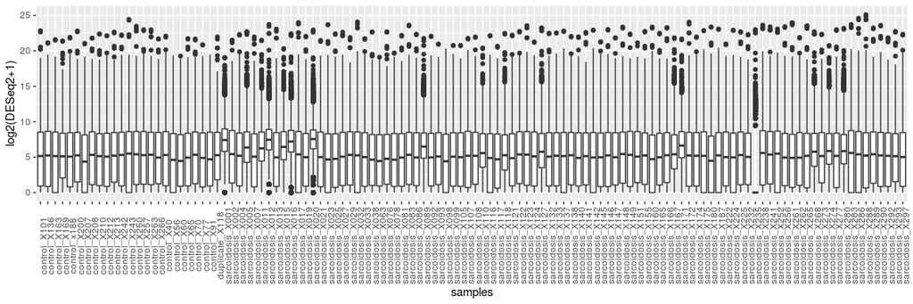

```r
fpkm<-fpkm.matrix

# filter out genes with no variation and centralize the data
temp.sd<-apply(fpkm,1,sd)
fpkm<-fpkm[temp.sd>0,]
removed_genes <- rownames(fpkm)[temp.sd<=0]

temp.names<-matrix(rep(colnames(fpkm),nrow(fpkm)),nrow=nrow(fpkm),byrow=T)
temp.vect<-matrix(rep(colnames(fpkm),nrow(fpkm)))

temp.data<-data.frame(expr=as.vector(as.matrix(fpkm)),samples=as.vector(temp.names),stringsAsFactors = F)
p <- ggplot(temp.data, aes(x=samples, y=expr)) +
  geom_boxplot()+
  theme(axis.text.x=element_text(angle=90)) +
  xlab("samples") +
  ylab("log2(DESeq2+1)")
#boxplot(as.vector(as.matrix(fpkm))~as.vector(temp.names))
p
```

```r
output.filepath<-file.path(home.dir,"scratch60/Laura_Koth","boxplot_persample_log2DESeq2.pdf")
ggsave(filename = output.filepath,plot=p,device="pdf",width=12,height=4,dpi=300)
cat("This boxplot has been saved as ",output.filepath,"\n",sep="")
```

```
This boxplot has been saved as /home/yanxiting/driver_Grace/scratch60/Laura_Koth/boxplot_persample_log2DESeq2.pdf
```

Then we visualize the 3D PCA plot.

```r
# visualize the PCA plot in 3D
library(rgl)
temp.vect<-unname(sapply(colnames(fpkm),my.element.extract,splitchar="_",index=1))
temp.vect[temp.vect=="duplicate"]<-"sarcoidosis"
my.colors<-c(rep("blue",ncol(fpkm)))
my.colors[temp.vect=="sarcoidosis"]<-"red"
open3d()
par3d(windowRect=c(300,300,300,300))
plot3d(my.projected[,1],my.projected[,2],my.projected[,3],xlab="PC 1",ylab="PC 2",zlab="PC 3",col=my.colors,type="s", size=0.6,box = F,axes = T)
identify3d(my.projected[,1],my.projected[,2],my.projected[,3],labels=colnames(fpkm),n=ncol(fpkm),plot=TRUE)
rglwidget()
```

[interactive chart not shown]

Load in the UCSF batch information to label the PCA plot using different variables.

```r
library(xlsx)
data.filepath<-file.path(home.dir,"scratch/GRADS/SARC_results/Results_summary_PBMC_hg38/baseline/Laura_Koth/ucsf_batch_quality.xlsx")
batch.data<-read.xlsx(data.filepath,sheetName = "Sheet1", header = T,check.names=F)
rownames(batch.data)<-paste(batch.data[,1],"_",batch.data[,2],sep="")

# match the rows of batch.data with columns in fpkm
batch.data<-batch.data[colnames(fpkm),]
```

Label the PCA plot using RNAextractiondate,RNAconcngµl, 260/280, 260/230, plate

RNAconcngµl:

```r
# visualize the PCA plot in 3D
my.label<-batch.data$RNAconcngµl
all.colors<-colorpanel(n=500,low="grey",high="red")
breaks=seq(from=min(my.label),to=max(my.label),length=501)
my.index<-numeric()
for(i in 1:length(my.label)){
  if(my.label[i]==min(my.label)){
    my.index<-c(my.index,1)
  }else{
    temp.index<-max((1:501)[breaks<my.label[i]])
    my.index<-c(my.index,temp.index)
  }
}

my.colors<-all.colors[my.index]

open3d()
par3d(windowRect=c(300,300,300,300))
plot3d(my.projected[,1],my.projected[,2],my.projected[,3],xlab="PC 1",ylab="PC 2",zlab="PC 3",col=my.colors,type="s", size=0.6,box = F,axes = T)
identify3d(my.projected[,1],my.projected[,2],my.projected[,3],labels=colnames(fpkm),n=ncol(fpkm),plot=TRUE)
rglwidget()
```

[interactive chart not shown]

260/280:

```r
# visualize the PCA plot in 3D
my.label<-batch.data$`260/280`
all.colors<-colorpanel(n=500,low="grey",high="red")
breaks=seq(from=min(my.label),to=max(my.label),length=501)
my.index<-numeric()
for(i in 1:length(my.label)){
  if(my.label[i]==min(my.label)){
    my.index<-c(my.index,1)
  }else{
    temp.index<-max((1:501)[breaks<my.label[i]])
    my.index<-c(my.index,temp.index)
  }
}

my.colors<-all.colors[my.index]

open3d()
par3d(windowRect=c(300,300,300,300))
plot3d(my.projected[,1],my.projected[,2],my.projected[,3],xlab="PC 1",ylab="PC 2",zlab="PC 3",col=my.colors,type="s", size=0.6,box = F,axes = T)
identify3d(my.projected[,1],my.projected[,2],my.projected[,3],labels=colnames(fpkm),n=ncol(fpkm),plot=TRUE)
rglwidget()
```

[interactive chart not shown]

260/230:

```r
# visualize the PCA plot in 3D
my.label<-batch.data$`260/230`
all.colors<-colorpanel(n=500,low="grey",high="red")
breaks=seq(from=min(my.label),to=max(my.label),length=501)
my.index<-numeric()
for(i in 1:length(my.label)){
  if(my.label[i]==min(my.label)){
    my.index<-c(my.index,1)
  }else{
    temp.index<-max((1:501)[breaks<my.label[i]])
    my.index<-c(my.index,temp.index)
  }
}

my.colors<-all.colors[my.index]

open3d()
par3d(windowRect=c(300,300,300,300))
plot3d(my.projected[,1],my.projected[,2],my.projected[,3],xlab="PC 1",ylab="PC 2",zlab="PC 3",col=my.colors,type="s", size=0.6,box = F,axes = T)
identify3d(my.projected[,1],my.projected[,2],my.projected[,3],labels=colnames(fpkm),n=ncol(fpkm),plot=TRUE)
rglwidget()
```

[interactive chart not shown]

plate:

```r
# visualize the PCA plot in 3D
my.label<-batch.data$plate
my.colors<-my.color.gen.cat(my.label)$color.num

open3d()
par3d(windowRect=c(300,300,300,300))
plot3d(my.projected[,1],my.projected[,2],my.projected[,3],xlab="PC 1",ylab="PC 2",zlab="PC 3",col=my.colors,type="s", size=0.6,box = F,axes = T)
identify3d(my.projected[,1],my.projected[,2],my.projected[,3],labels=colnames(fpkm),n=ncol(fpkm),plot=TRUE)
rglwidget()
```

[interactive chart not shown]

date:

```r
# visualize the PCA plot in 3D
my.label<-batch.data$RNAextractiondate
my.colors<-my.color.gen.cat(my.label)$color.num

open3d()
par3d(windowRect=c(300,300,300,300))
plot3d(my.projected[,1],my.projected[,2],my.projected[,3],xlab="PC 1",ylab="PC 2",zlab="PC 3",col=my.colors,type="s", size=0.6,box = F,axes = T)
identify3d(my.projected[,1],my.projected[,2],my.projected[,3],labels=colnames(fpkm),n=ncol(fpkm),plot=TRUE)
rglwidget()
```

[interactive chart not shown]

## DESeq2 (no log2)

We first conduct PCA analysis to identify potential outliers in the UCSF cohort.

```r
# load in the normalized count matrix
home.dir<-"/home/yanxiting/driver_Grace"
source(file.path(home.dir,"Rprogram/my_functions.R"))

deseq2.filepath<-file.path(home.dir,"scratch60/Laura_Koth","DESeq2_normalized.RDS")
my.data<-readRDS(deseq2.filepath,refhook = NULL)

anno.data<-my.data[,1:6]
rownames(my.data)<-as.matrix(my.data)[,1]
fpkm.matrix<-my.data[,7:ncol(my.data)]

#log2 transform, if yes, do the analysis on log2(fpkm.matrix+1) to avoid log2(0) transformation
log2.transform<-F
if(log2.transform){
fpkm.matrix<-fpkm.matrix+1
fpkm.matrix<-log(fpkm.matrix,base=2)
}
fpkm<-fpkm.matrix

# filter out genes with no variation and centralize the data
temp.sd<-apply(fpkm,1,sd)
fpkm<-fpkm[temp.sd>0,]
removed_genes <- rownames(fpkm)[temp.sd<=0]

#Conduct PCA
fpkm.norm<-my.normalize(fpkm)
my.svd<-svd(fpkm.norm)
cat("The cumulative proportion of variation explained by the top 3 PCs:\n",cumsum(my.svd$d^2/sum(my.svd$d^2))[1:3],"\n")
```

```
The cumulative proportion of variation explained by the top 3 PCs:
 0.3814065 0.5557584 0.6454647
```

```r
my.projected<-t(fpkm.norm)%*%my.svd$u
my.distance<-dist(my.projected, method = "euclidean", diag = FALSE, upper = FALSE)
```

First, we look at the data distribution across different genes for each sample.

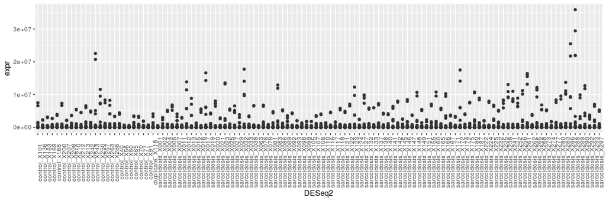

```r
fpkm<-fpkm.matrix

# filter out genes with no variation and centralize the data
temp.sd<-apply(fpkm,1,sd)
fpkm<-fpkm[temp.sd>0,]
removed_genes <- rownames(fpkm)[temp.sd<=0]

temp.names<-matrix(rep(colnames(fpkm),nrow(fpkm)),nrow=nrow(fpkm),byrow=T)
temp.vect<-matrix(rep(colnames(fpkm),nrow(fpkm)))

temp.data<-data.frame(expr=as.vector(as.matrix(fpkm)),samples=as.vector(temp.names),stringsAsFactors = F)
p <- ggplot(temp.data, aes(x=samples, y=expr)) +
  geom_boxplot()+
  theme(axis.text.x=element_text(angle=90)) +
  xlab("DESeq2")
#boxplot(as.vector(as.matrix(fpkm))~as.vector(temp.names))
p
```

```r
output.filepath<-file.path(home.dir,"scratch60/Laura_Koth","boxplot_persample_DESeq2.pdf")
ggsave(filename = output.filepath,plot=p,device="pdf",width=12,height=4,dpi=300)
cat("This boxplot has been saved as ",output.filepath,"\n",sep="")
```

```
This boxplot has been saved as /home/yanxiting/driver_Grace/scratch60/Laura_Koth/boxplot_persample_DESeq2.pdf
```

Then we visualize the 3D PCA plot.

```r
# visualize the PCA plot in 3D
library(rgl)
temp.vect<-unname(sapply(colnames(fpkm),my.element.extract,splitchar="_",index=1))
temp.vect[temp.vect=="duplicate"]<-"sarcoidosis"
my.colors<-c(rep("blue",ncol(fpkm)))
my.colors[temp.vect=="sarcoidosis"]<-"red"
open3d()
par3d(windowRect=c(300,300,300,300))
plot3d(my.projected[,1],my.projected[,2],my.projected[,3],xlab="PC 1",ylab="PC 2",zlab="PC 3",col=my.colors,type="s", size=0.6,box = F,axes = T)
identify3d(my.projected[,1],my.projected[,2],my.projected[,3],labels=colnames(fpkm),n=ncol(fpkm),plot=TRUE)
rglwidget()
```

[interactive chart not shown]

Load in the UCSF batch information to label the PCA plot using different variables.

```r
library(xlsx)
data.filepath<-file.path(home.dir,"scratch/GRADS/SARC_results/Results_summary_PBMC_hg38/baseline/Laura_Koth/ucsf_batch_quality.xlsx")
batch.data<-read.xlsx(data.filepath,sheetName = "Sheet1", header = T,check.names=F)
rownames(batch.data)<-paste(batch.data[,1],"_",batch.data[,2],sep="")

# match the rows of batch.data with columns in fpkm
batch.data<-batch.data[colnames(fpkm),]
```

Label the PCA plot using RNAextractiondate,RNAconcngµl, 260/280, 260/230, plate

RNAconcngµl:

```r
# visualize the PCA plot in 3D
my.label<-batch.data$RNAconcngµl
all.colors<-colorpanel(n=500,low="grey",high="red")
breaks=seq(from=min(my.label),to=max(my.label),length=501)
my.index<-numeric()
for(i in 1:length(my.label)){
  if(my.label[i]==min(my.label)){
    my.index<-c(my.index,1)
  }else{
    temp.index<-max((1:501)[breaks<my.label[i]])
    my.index<-c(my.index,temp.index)
  }
}

my.colors<-all.colors[my.index]

open3d()
par3d(windowRect=c(300,300,300,300))
plot3d(my.projected[,1],my.projected[,2],my.projected[,3],xlab="PC 1",ylab="PC 2",zlab="PC 3",col=my.colors,type="s", size=0.6,box = F,axes = T)
identify3d(my.projected[,1],my.projected[,2],my.projected[,3],labels=colnames(fpkm),n=ncol(fpkm),plot=TRUE)
rglwidget()
```

[interactive chart not shown]

260/280:

```r
# visualize the PCA plot in 3D
my.label<-batch.data$`260/280`
all.colors<-colorpanel(n=500,low="grey",high="red")
breaks=seq(from=min(my.label),to=max(my.label),length=501)
my.index<-numeric()
for(i in 1:length(my.label)){
  if(my.label[i]==min(my.label)){
    my.index<-c(my.index,1)
  }else{
    temp.index<-max((1:501)[breaks<my.label[i]])
    my.index<-c(my.index,temp.index)
  }
}

my.colors<-all.colors[my.index]

open3d()
par3d(windowRect=c(300,300,300,300))
plot3d(my.projected[,1],my.projected[,2],my.projected[,3],xlab="PC 1",ylab="PC 2",zlab="PC 3",col=my.colors,type="s", size=0.6,box = F,axes = T)
identify3d(my.projected[,1],my.projected[,2],my.projected[,3],labels=colnames(fpkm),n=ncol(fpkm),plot=TRUE)
rglwidget()
```

[interactive chart not shown]

260/230:

```r
# visualize the PCA plot in 3D
my.label<-batch.data$`260/230`
all.colors<-colorpanel(n=500,low="grey",high="red")
breaks=seq(from=min(my.label),to=max(my.label),length=501)
my.index<-numeric()
for(i in 1:length(my.label)){
  if(my.label[i]==min(my.label)){
    my.index<-c(my.index,1)
  }else{
    temp.index<-max((1:501)[breaks<my.label[i]])
    my.index<-c(my.index,temp.index)
  }
}

my.colors<-all.colors[my.index]

open3d()
par3d(windowRect=c(300,300,300,300))
plot3d(my.projected[,1],my.projected[,2],my.projected[,3],xlab="PC 1",ylab="PC 2",zlab="PC 3",col=my.colors,type="s", size=0.6,box = F,axes = T)
identify3d(my.projected[,1],my.projected[,2],my.projected[,3],labels=colnames(fpkm),n=ncol(fpkm),plot=TRUE)
rglwidget()
```

[interactive chart not shown]

plate:

```r
# visualize the PCA plot in 3D
my.label<-batch.data$plate
my.colors<-my.color.gen.cat(my.label)$color.num

open3d()
par3d(windowRect=c(300,300,300,300))
plot3d(my.projected[,1],my.projected[,2],my.projected[,3],xlab="PC 1",ylab="PC 2",zlab="PC 3",col=my.colors,type="s", size=0.6,box = F,axes = T)
identify3d(my.projected[,1],my.projected[,2],my.projected[,3],labels=colnames(fpkm),n=ncol(fpkm),plot=TRUE)
rglwidget()
```

[interactive chart not shown]

date:

```r
# visualize the PCA plot in 3D
my.label<-batch.data$RNAextractiondate
my.colors<-my.color.gen.cat(my.label)$color.num

open3d()
par3d(windowRect=c(300,300,300,300))
plot3d(my.projected[,1],my.projected[,2],my.projected[,3],xlab="PC 1",ylab="PC 2",zlab="PC 3",col=my.colors,type="s", size=0.6,box = F,axes = T)
identify3d(my.projected[,1],my.projected[,2],my.projected[,3],labels=colnames(fpkm),n=ncol(fpkm),plot=TRUE)
rglwidget()
```

[interactive chart not shown]

## TPM (log2)

We first conduct PCA analysis to identify potential outliers in the UCSF cohort.

```r
# load in the normalized count matrix
home.dir<-"/home/yanxiting/driver_Grace"
source(file.path(home.dir,"Rprogram/my_functions.R"))

deseq2.filepath<-file.path(home.dir,"scratch60/Laura_Koth","TPM_all.RDS")
my.data<-readRDS(deseq2.filepath,refhook = NULL)

anno.data<-my.data[,1:5]
#rownames(my.data)<-as.matrix(my.data)[,1]
fpkm.matrix<-my.data[,6:ncol(my.data)]

#log2 transform, if yes, do the analysis on log2(fpkm.matrix+1) to avoid log2(0) transformation
log2.transform<-T
if(log2.transform){
fpkm.matrix<-fpkm.matrix+1
fpkm.matrix<-log(fpkm.matrix,base=2)
}
fpkm<-fpkm.matrix

# filter out genes with no variation and centralize the data
temp.sd<-apply(fpkm,1,sd)
fpkm<-fpkm[temp.sd>0,]
removed_genes <- rownames(fpkm)[temp.sd<=0]

#Conduct PCA
fpkm.norm<-my.normalize(fpkm)
my.svd<-svd(fpkm.norm)
cat("The cumulative proportion of variation explained by the top 3 PCs:\n",cumsum(my.svd$d^2/sum(my.svd$d^2))[1:3],"\n")
```

```
The cumulative proportion of variation explained by the top 3 PCs:
 0.6332303 0.8081691 0.8550039
```

```r
my.projected<-t(fpkm.norm)%*%my.svd$u
my.distance<-dist(my.projected, method = "euclidean", diag = FALSE, upper = FALSE)
```

First, we look at the data distribution across different genes for each sample.

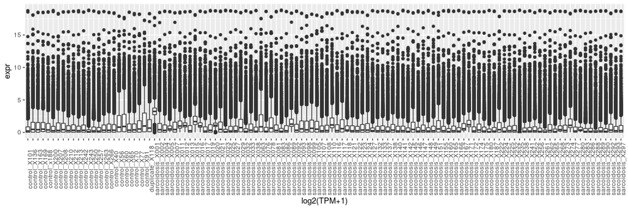

```r
fpkm<-fpkm.matrix

# filter out genes with no variation and centralize the data
temp.sd<-apply(fpkm,1,sd)
fpkm<-fpkm[temp.sd>0,]
removed_genes <- rownames(fpkm)[temp.sd<=0]

temp.names<-matrix(rep(colnames(fpkm),nrow(fpkm)),nrow=nrow(fpkm),byrow=T)
temp.vect<-matrix(rep(colnames(fpkm),nrow(fpkm)))

temp.data<-data.frame(expr=as.vector(as.matrix(fpkm)),samples=as.vector(temp.names),stringsAsFactors = F)
p <- ggplot(temp.data, aes(x=samples, y=expr)) +
  geom_boxplot()+
  theme(axis.text.x=element_text(angle=90)) +
  xlab("log2(TPM+1)")
#boxplot(as.vector(as.matrix(fpkm))~as.vector(temp.names))
p
```

```r
output.filepath<-file.path(home.dir,"scratch60/Laura_Koth","boxplot_persample_log2TPM.pdf")
ggsave(filename = output.filepath,plot=p,device="pdf",width=12,height=4,dpi=300)
cat("This boxplot has been saved as ",output.filepath,"\n",sep="")
```

```
This boxplot has been saved as /home/yanxiting/driver_Grace/scratch60/Laura_Koth/boxplot_persample_log2TPM.pdf
```

Then we visualize the 3D PCA plot.

```r
# visualize the PCA plot in 3D
library(rgl)
temp.vect<-unname(sapply(colnames(fpkm),my.element.extract,splitchar="_",index=1))
temp.vect[temp.vect=="duplicate"]<-"sarcoidosis"
my.colors<-c(rep("blue",ncol(fpkm)))
my.colors[temp.vect=="sarcoidosis"]<-"red"
open3d()
par3d(windowRect=c(300,300,300,300))
plot3d(my.projected[,1],my.projected[,2],my.projected[,3],xlab="PC 1",ylab="PC 2",zlab="PC 3",col=my.colors,type="s", size=0.6,box = F,axes = T)
identify3d(my.projected[,1],my.projected[,2],my.projected[,3],labels=colnames(fpkm),n=ncol(fpkm),plot=TRUE)
rglwidget()
```

[interactive chart not shown]

Load in the UCSF batch information to label the PCA plot using different variables.

```r
library(xlsx)
data.filepath<-file.path(home.dir,"scratch/GRADS/SARC_results/Results_summary_PBMC_hg38/baseline/Laura_Koth/ucsf_batch_quality.xlsx")
batch.data<-read.xlsx(data.filepath,sheetName = "Sheet1", header = T,check.names=F)
rownames(batch.data)<-paste(batch.data[,1],"_",batch.data[,2],sep="")

# match the rows of batch.data with columns in fpkm
batch.data<-batch.data[colnames(fpkm),]
```

Label the PCA plot using RNAextractiondate,RNAconcngµl, 260/280, 260/230, plate

RNAconcngµl:

```r
# visualize the PCA plot in 3D
my.label<-batch.data$RNAconcngµl
all.colors<-colorpanel(n=500,low="grey",high="red")
breaks=seq(from=min(my.label),to=max(my.label),length=501)
my.index<-numeric()
for(i in 1:length(my.label)){
  if(my.label[i]==min(my.label)){
    my.index<-c(my.index,1)
  }else{
    temp.index<-max((1:501)[breaks<my.label[i]])
    my.index<-c(my.index,temp.index)
  }
}

my.colors<-all.colors[my.index]

open3d()
par3d(windowRect=c(300,300,300,300))
plot3d(my.projected[,1],my.projected[,2],my.projected[,3],xlab="PC 1",ylab="PC 2",zlab="PC 3",col=my.colors,type="s", size=0.6,box = F,axes = T)
identify3d(my.projected[,1],my.projected[,2],my.projected[,3],labels=colnames(fpkm),n=ncol(fpkm),plot=TRUE)
rglwidget()
```

[interactive chart not shown]

260/280:

```r
# visualize the PCA plot in 3D
my.label<-batch.data$`260/280`
all.colors<-colorpanel(n=500,low="grey",high="red")
breaks=seq(from=min(my.label),to=max(my.label),length=501)
my.index<-numeric()
for(i in 1:length(my.label)){
  if(my.label[i]==min(my.label)){
    my.index<-c(my.index,1)
  }else{
    temp.index<-max((1:501)[breaks<my.label[i]])
    my.index<-c(my.index,temp.index)
  }
}

my.colors<-all.colors[my.index]

open3d()
par3d(windowRect=c(300,300,300,300))
plot3d(my.projected[,1],my.projected[,2],my.projected[,3],xlab="PC 1",ylab="PC 2",zlab="PC 3",col=my.colors,type="s", size=0.6,box = F,axes = T)
identify3d(my.projected[,1],my.projected[,2],my.projected[,3],labels=colnames(fpkm),n=ncol(fpkm),plot=TRUE)
rglwidget()
```

[interactive chart not shown]

260/230:

```r
# visualize the PCA plot in 3D
my.label<-batch.data$`260/230`
all.colors<-colorpanel(n=500,low="grey",high="red")
breaks=seq(from=min(my.label),to=max(my.label),length=501)
my.index<-numeric()
for(i in 1:length(my.label)){
  if(my.label[i]==min(my.label)){
    my.index<-c(my.index,1)
  }else{
    temp.index<-max((1:501)[breaks<my.label[i]])
    my.index<-c(my.index,temp.index)
  }
}

my.colors<-all.colors[my.index]

open3d()
par3d(windowRect=c(300,300,300,300))
plot3d(my.projected[,1],my.projected[,2],my.projected[,3],xlab="PC 1",ylab="PC 2",zlab="PC 3",col=my.colors,type="s", size=0.6,box = F,axes = T)
identify3d(my.projected[,1],my.projected[,2],my.projected[,3],labels=colnames(fpkm),n=ncol(fpkm),plot=TRUE)
rglwidget()
```

[interactive chart not shown]

plate:

```r
# visualize the PCA plot in 3D
my.label<-batch.data$plate
my.colors<-my.color.gen.cat(my.label)$color.num

open3d()
par3d(windowRect=c(300,300,300,300))
plot3d(my.projected[,1],my.projected[,2],my.projected[,3],xlab="PC 1",ylab="PC 2",zlab="PC 3",col=my.colors,type="s", size=0.6,box = F,axes = T)
identify3d(my.projected[,1],my.projected[,2],my.projected[,3],labels=colnames(fpkm),n=ncol(fpkm),plot=TRUE)
rglwidget()
```

[interactive chart not shown]

date:

```r
# visualize the PCA plot in 3D
my.label<-batch.data$RNAextractiondate
my.colors<-my.color.gen.cat(my.label)$color.num

open3d()
par3d(windowRect=c(300,300,300,300))
plot3d(my.projected[,1],my.projected[,2],my.projected[,3],xlab="PC 1",ylab="PC 2",zlab="PC 3",col=my.colors,type="s", size=0.6,box = F,axes = T)
identify3d(my.projected[,1],my.projected[,2],my.projected[,3],labels=colnames(fpkm),n=ncol(fpkm),plot=TRUE)
rglwidget()
```

[interactive chart not shown]

## TPM (no log2)

We first conduct PCA analysis to identify potential outliers in the UCSF cohort.

```r
# load in the normalized count matrix
home.dir<-"/home/yanxiting/driver_Grace"
source(file.path(home.dir,"Rprogram/my_functions.R"))

deseq2.filepath<-file.path(home.dir,"scratch60/Laura_Koth","TPM_all.RDS")
my.data<-readRDS(deseq2.filepath,refhook = NULL)

anno.data<-my.data[,1:5]
#rownames(my.data)<-as.matrix(my.data)[,1]
fpkm.matrix<-my.data[,6:ncol(my.data)]

#log2 transform, if yes, do the analysis on log2(fpkm.matrix+1) to avoid log2(0) transformation
log2.transform<-F
if(log2.transform){
fpkm.matrix<-fpkm.matrix+1
fpkm.matrix<-log(fpkm.matrix,base=2)
}
fpkm<-fpkm.matrix

# filter out genes with no variation and centralize the data
temp.sd<-apply(fpkm,1,sd)
fpkm<-fpkm[temp.sd>0,]
removed_genes <- rownames(fpkm)[temp.sd<=0]

#Conduct PCA
fpkm.norm<-my.normalize(fpkm)
my.svd<-svd(fpkm.norm)
cat("The cumulative proportion of variation explained by the top 3 PCs:\n",cumsum(my.svd$d^2/sum(my.svd$d^2))[1:3],"\n")
```

```
The cumulative proportion of variation explained by the top 3 PCs:
 0.6723132 0.821242 0.8728068
```

```r
my.projected<-t(fpkm.norm)%*%my.svd$u
my.distance<-dist(my.projected, method = "euclidean", diag = FALSE, upper = FALSE)
```

First, we look at the data distribution across different genes for each sample.

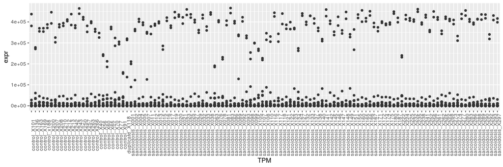

```r
fpkm<-fpkm.matrix

# filter out genes with no variation and centralize the data
temp.sd<-apply(fpkm,1,sd)
fpkm<-fpkm[temp.sd>0,]
removed_genes <- rownames(fpkm)[temp.sd<=0]

temp.names<-matrix(rep(colnames(fpkm),nrow(fpkm)),nrow=nrow(fpkm),byrow=T)
temp.vect<-matrix(rep(colnames(fpkm),nrow(fpkm)))

temp.data<-data.frame(expr=as.vector(as.matrix(fpkm)),samples=as.vector(temp.names),stringsAsFactors = F)
p <- ggplot(temp.data, aes(x=samples, y=expr)) +
  geom_boxplot()+
  theme(axis.text.x=element_text(angle=90)) +
  xlab("TPM")
#boxplot(as.vector(as.matrix(fpkm))~as.vector(temp.names))
p
```

```r
output.filepath<-file.path(home.dir,"scratch60/Laura_Koth","boxplot_persample_TPM.pdf")
ggsave(filename = output.filepath,plot=p,device="pdf",width=12,height=4,dpi=300)
cat("This boxplot has been saved as ",output.filepath,"\n",sep="")
```

```
This boxplot has been saved as /home/yanxiting/driver_Grace/scratch60/Laura_Koth/boxplot_persample_TPM.pdf
```

Then we visualize the 3D PCA plot.

```r
# visualize the PCA plot in 3D
library(rgl)
temp.vect<-unname(sapply(colnames(fpkm),my.element.extract,splitchar="_",index=1))
temp.vect[temp.vect=="duplicate"]<-"sarcoidosis"
my.colors<-c(rep("blue",ncol(fpkm)))
my.colors[temp.vect=="sarcoidosis"]<-"red"
open3d()
par3d(windowRect=c(300,300,300,300))
plot3d(my.projected[,1],my.projected[,2],my.projected[,3],xlab="PC 1",ylab="PC 2",zlab="PC 3",col=my.colors,type="s", size=0.6,box = F,axes = T)
identify3d(my.projected[,1],my.projected[,2],my.projected[,3],labels=colnames(fpkm),n=ncol(fpkm),plot=TRUE)
rglwidget()
```

[interactive chart not shown]

```r
# visualize the PCA plot in 3D
library(rgl)
temp.vect<-unname(sapply(colnames(fpkm),my.element.extract,splitchar="_",index=1))
temp.vect[temp.vect=="duplicate"]<-"sarcoidosis"
my.colors<-c(rep("blue",ncol(fpkm)))
my.colors[temp.vect=="sarcoidosis"]<-"red"
open3d()
par3d(windowRect=c(300,300,300,300))
plot3d(my.projected[,1],my.projected[,2],my.projected[,3],xlab="PC 1",ylab="PC 2",zlab="PC 3",col=my.colors,type="s", size=0.6,box = F,axes = T)
identify3d(my.projected[,1],my.projected[,2],my.projected[,3],labels=colnames(fpkm),n=ncol(fpkm),plot=TRUE)
rglwidget()
```

[interactive chart not shown]

Load in the UCSF batch information to label the PCA plot using different variables.

```r
library(xlsx)
data.filepath<-file.path(home.dir,"scratch/GRADS/SARC_results/Results_summary_PBMC_hg38/baseline/Laura_Koth/ucsf_batch_quality.xlsx")
batch.data<-read.xlsx(data.filepath,sheetName = "Sheet1", header = T,check.names=F)
rownames(batch.data)<-paste(batch.data[,1],"_",batch.data[,2],sep="")

# match the rows of batch.data with columns in fpkm
batch.data<-batch.data[colnames(fpkm),]
```

Label the PCA plot using RNAextractiondate,RNAconcngµl, 260/280, 260/230, plate

RNAconcngµl:

```r
# visualize the PCA plot in 3D
my.label<-batch.data$RNAconcngµl
all.colors<-colorpanel(n=500,low="grey",high="red")
breaks=seq(from=min(my.label),to=max(my.label),length=501)
my.index<-numeric()
for(i in 1:length(my.label)){
  if(my.label[i]==min(my.label)){
    my.index<-c(my.index,1)
  }else{
    temp.index<-max((1:501)[breaks<my.label[i]])
    my.index<-c(my.index,temp.index)
  }
}

my.colors<-all.colors[my.index]

open3d()
par3d(windowRect=c(300,300,300,300))
plot3d(my.projected[,1],my.projected[,2],my.projected[,3],xlab="PC 1",ylab="PC 2",zlab="PC 3",col=my.colors,type="s", size=0.6,box = F,axes = T)
identify3d(my.projected[,1],my.projected[,2],my.projected[,3],labels=colnames(fpkm),n=ncol(fpkm),plot=TRUE)
rglwidget()
```

[interactive chart not shown]

260/280:

```r
# visualize the PCA plot in 3D
my.label<-batch.data$`260/280`
all.colors<-colorpanel(n=500,low="grey",high="red")
breaks=seq(from=min(my.label),to=max(my.label),length=501)
my.index<-numeric()
for(i in 1:length(my.label)){
  if(my.label[i]==min(my.label)){
    my.index<-c(my.index,1)
  }else{
    temp.index<-max((1:501)[breaks<my.label[i]])
    my.index<-c(my.index,temp.index)
  }
}

my.colors<-all.colors[my.index]

open3d()
par3d(windowRect=c(300,300,300,300))
plot3d(my.projected[,1],my.projected[,2],my.projected[,3],xlab="PC 1",ylab="PC 2",zlab="PC 3",col=my.colors,type="s", size=0.6,box = F,axes = T)
identify3d(my.projected[,1],my.projected[,2],my.projected[,3],labels=colnames(fpkm),n=ncol(fpkm),plot=TRUE)
rglwidget()
```

[interactive chart not shown]

260/230:

```r
# visualize the PCA plot in 3D
my.label<-batch.data$`260/230`
all.colors<-colorpanel(n=500,low="grey",high="red")
breaks=seq(from=min(my.label),to=max(my.label),length=501)
my.index<-numeric()
for(i in 1:length(my.label)){
  if(my.label[i]==min(my.label)){
    my.index<-c(my.index,1)
  }else{
    temp.index<-max((1:501)[breaks<my.label[i]])
    my.index<-c(my.index,temp.index)
  }
}

my.colors<-all.colors[my.index]

open3d()
par3d(windowRect=c(300,300,300,300))
plot3d(my.projected[,1],my.projected[,2],my.projected[,3],xlab="PC 1",ylab="PC 2",zlab="PC 3",col=my.colors,type="s", size=0.6,box = F,axes = T)
identify3d(my.projected[,1],my.projected[,2],my.projected[,3],labels=colnames(fpkm),n=ncol(fpkm),plot=TRUE)
rglwidget()
```

[interactive chart not shown]

plate:

```r
# visualize the PCA plot in 3D
my.label<-batch.data$plate
my.colors<-my.color.gen.cat(my.label)$color.num

open3d()
par3d(windowRect=c(300,300,300,300))
plot3d(my.projected[,1],my.projected[,2],my.projected[,3],xlab="PC 1",ylab="PC 2",zlab="PC 3",col=my.colors,type="s", size=0.6,box = F,axes = T)
identify3d(my.projected[,1],my.projected[,2],my.projected[,3],labels=colnames(fpkm),n=ncol(fpkm),plot=TRUE)
rglwidget()
```

[interactive chart not shown]

date:

```r
# visualize the PCA plot in 3D
my.label<-batch.data$RNAextractiondate
my.colors<-my.color.gen.cat(my.label)$color.num

open3d()
par3d(windowRect=c(300,300,300,300))
plot3d(my.projected[,1],my.projected[,2],my.projected[,3],xlab="PC 1",ylab="PC 2",zlab="PC 3",col=my.colors,type="s", size=0.6,box = F,axes = T)
identify3d(my.projected[,1],my.projected[,2],my.projected[,3],labels=colnames(fpkm),n=ncol(fpkm),plot=TRUE)
rglwidget()
```

[interactive chart not shown]